# Самостоятельная работа. Lab 5

Сегодня вы поработаете с двумя датасетами:

1. Выручка топовых компаний России за 2015-2016гг. по данным сайта [Эксперт](http://expert.ru/northwest/2016/45/rejting-250-krupnejshih-kompanij-szfo/)
2. Вопросы и ответы с тегом R на сайте stackoverflow.com (ваш помощник на ближайшие два года)

## Часть 1. Топ-250 компаний.

Данные будем загружать из файла. Для этого используем функцию read_csv.

```r
library(dplyr)
```

```r
library(ggplot2)
library(readr)
?read_csv
top_companies <- read_csv("~/shared/minor2_2018/1-intro/data/top_companies.csv")
top_companies = top_companies %>% select(brand = `Бренды`,
                                         company = `Наименование компании`,
                                         owner = `Ключевые собственники`,
                                         income2016 = `Вырчука, 2016 г.`,
                                         income2015 = `Выручка, 2015 г.`,
                                         region = `Регион`,
                                         industry = `Отрасль`)
```

Постройте график распределения выручки (представлена в млн. рублей) компаний за 2016 год (income2016). Напоминаем, что для того, чтобы проанализировать распределение числовой переменной, мы используем гистограмму или боксплот.

(!) почему нельзя использовать параметр “binwidth = 1”? Как вы думаете? Answer: Потому что в колонке ‘income2016’ есть широкое распространение данных (полтора миллион..). Если мы используем ‘binwidth = 1’, у нас будет миллион колонк в гистограме.

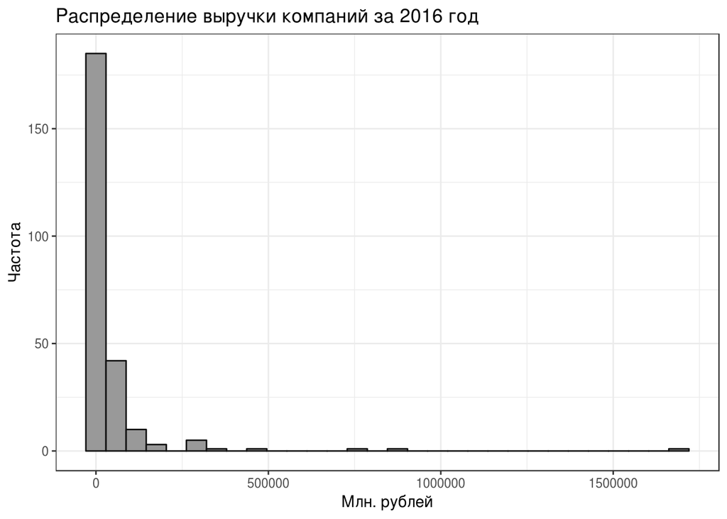

```r
ggplot() + geom_histogram(data = top_companies, aes(x = income2016), fill = '#999999', col = '#111111')+
   ggtitle("Распределение выручки компаний за 2016 год")+
  xlab("Млн. рублей")+
  ylab("Частота")+
  theme_bw()
```

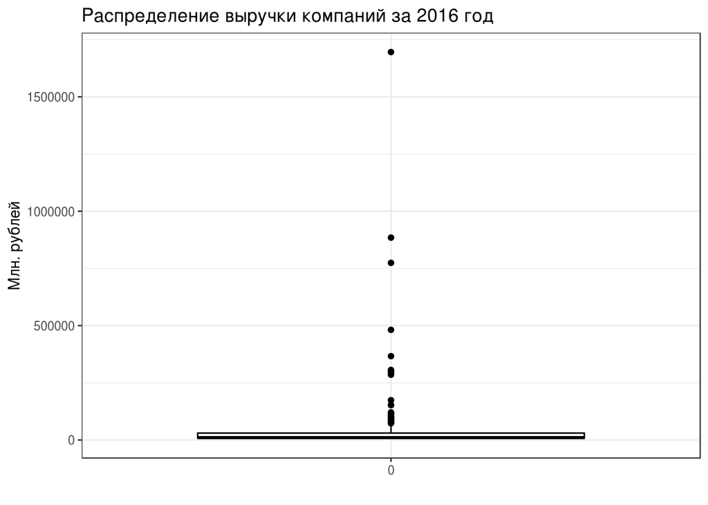

```r
ggplot() + geom_boxplot(data= top_companies, aes(x = factor(0), y = income2016), fill = '#ffffff', col = '#000000') +
  xlab(" ")+
  ylab("Млн. рублей")+
  ggtitle("Распределение выручки компаний за 2016 год")+
  theme_bw()
```

Как вы видите, у нас есть очень сильные выбросы, из-за которых бОльшая часть нашего распределения находится у самого начала оси X или же, в случае боксплота, у начала оси Y. Cкладывается впечатление, что выручка для большинства компаний равна 0, но это же не так!. Давайте, чтобы немного улучшить ситуацию, оставим только 95 % наблюдений и по ним построим график. При помощи функции `quantile(top_companies$income2016, 0.95)` мы можем узнать, что значение, которое отделяет 95 % наблюдений – это 138303.7. Давайте оставим только те наблюдения, у которых income меньше 138303.7, и снова построим график.

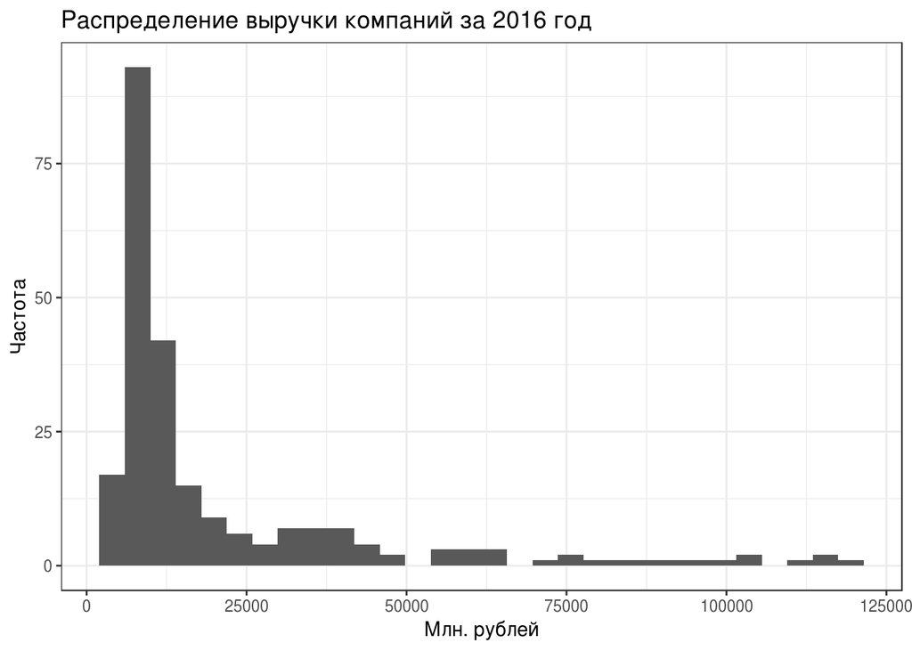

```r
q = quantile(top_companies$income2016, 0.95)

top_companies %>%
  filter(income2016 < q) %>%
  ggplot() +
  geom_histogram(aes(x=income2016))+
  ggtitle("Распределение выручки компаний за 2016 год")+
  xlab("Млн. рублей")+
  ylab("Частота")+
  theme_bw()
```

Какому ключевому собственнику (owner) принадлежит наибольшее количество брендов из нашего топа компаний. Из финального списка удалите NA (функция `na.omit`) и отавьте верхние 5 значений. Для того, чтобы оставить первые 5 значений, можно использовать функцию `top_n`

```r
?top_n
top_companies %>% group_by(owner) %>% dplyr::summarize(brand_count = n()) %>% arrange(-brand_count) %>% na.omit() %>% top_n(5)
```

```
## # A tibble: 5 x 2
##   owner                             brand_count
##   <chr>                                   <int>
## 1 Иностранные компании (Кипр)                37
## 2 Граждане России                            24
## 3 РФ (субъект РФ)                            20
## 4 Иностранная компания (Нидерланды)           7
## 5 ПАО Газпром                                 3
```

Создайте новую колонку, в которой посчитаете разницу в прибыли между 2016 и 2015 годами. Какая компания больше всех прибавила в позициях?

```r
top5_companies = top_companies %>% mutate(difference_income = income2016 - income2015) %>% arrange(-difference_income) %>% top_n(5)
top5_companies
```

```
## # A tibble: 5 x 8
##   brand    company    owner      income2016 income2015 region industry
##   <chr>    <chr>      <chr>           <int>      <dbl> <chr>  <chr>
## 1 Пятероч… Агроторг   Холдинг X5     481713     228909 СПб    FMCG ритейл
## 2 ¾        Стройгазк… Иностранн…     153019      40121 СПб    Промышленно…
## 3 Лента    Лента      Free floa…     306352     252763 СПб    FMCG ритейл
## 4 Газпром… Газпром Н… ПАО Газпр…    1695764    1655775 СПб    ТЭК
## 5 Россия,… АК Россия  ПАО Аэроф…      73189      38755 СПб    Авиатранспо…
## # ... with 1 more variable: difference_income <dbl>
```

Найдите топ-3 регионов по медианной выручке компаний (income2016). Запишите результат в дф под названием top3_regions.

```r
top3_regions = top_companies %>% group_by(region) %>% summarize(median_income = median(income2016))%>% top_n(3, median_income)
top3_regions
```

```
## # A tibble: 3 x 2
##   region    median_income
##   <chr>             <dbl>
## 1 Вол. Обл.         23042
## 2 НАО               60603
## 3 СЗФО              49376
```

Из оригинального датасета оставьте только компании, находящиеся в топе-3 регионов, полученные в предыдущем задании – поможет оператор `%in%`. Чтобы успешно использовать оператор `%in%`, нужно, при использовании функции filter, в то место, куда мы обычно записываем логические выражения, на основе которых фильтруем датасеты, записать следующее: `region %in% top3_regions$region`. Таким образом, мы оставляем в векторе region только те значения, которые есть в векторе top3_regions$region. Постройте график, чтобы сравнить распределение выручки компаний в этих регионах.

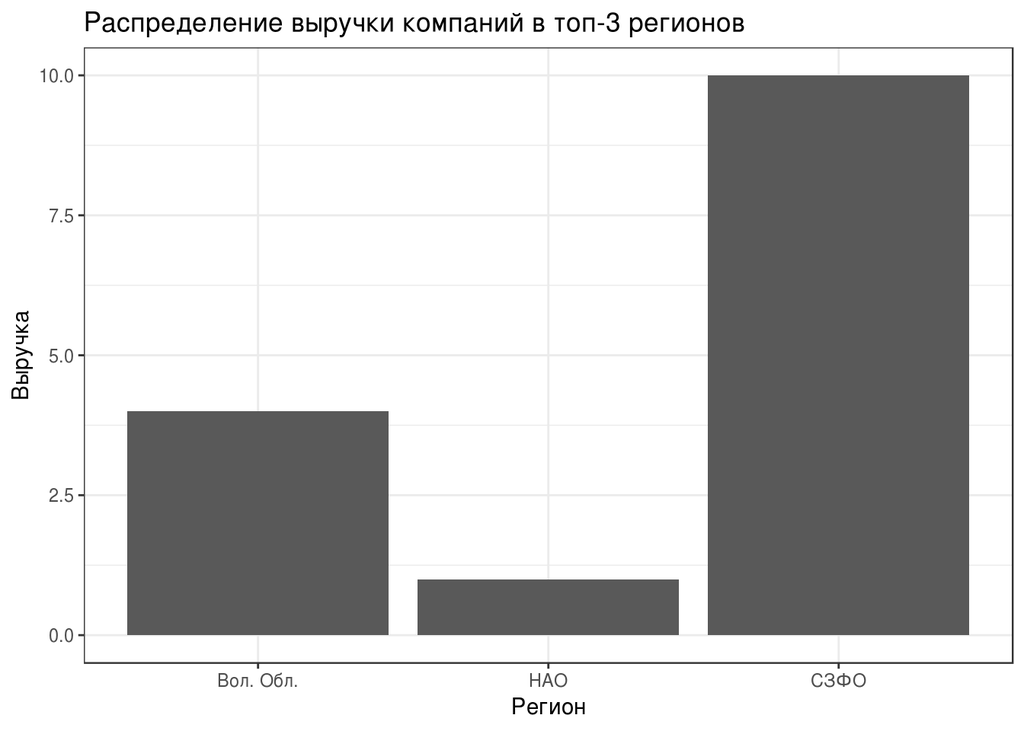

```r
p = top_companies %>% filter(region %in% top3_regions$region)
ggplot(data = p)+
  geom_bar(aes(x = region))+
   ggtitle("Распределение выручки компаний в топ-3 регионов")+
  xlab("Регион")+
  ylab("Выручка")+
  theme_bw()
```

Найдите топ-5 отраслей (industry) с максимальными выручками брендов и постройте bar plot, в котором на оси X будут названия отраслей, а ось Y будет представлять максимальные значения, которые мы нашли. Не забудьдте, что если мы хотим в качестве значений оси Y использовать значения конкретного столбца, нам нужно указать, что `stat = "identity"`. Сделайте так, чтобы столбцы в диаграмме шли по убыванию значения max. Для этого в aes для оси X напишите не просто industry, a `reorder(industry, -max)`.

```r
top5 = top_companies %>% group_by(industry) %>% summarise(profit = max(income2016)) %>% top_n(5)
```

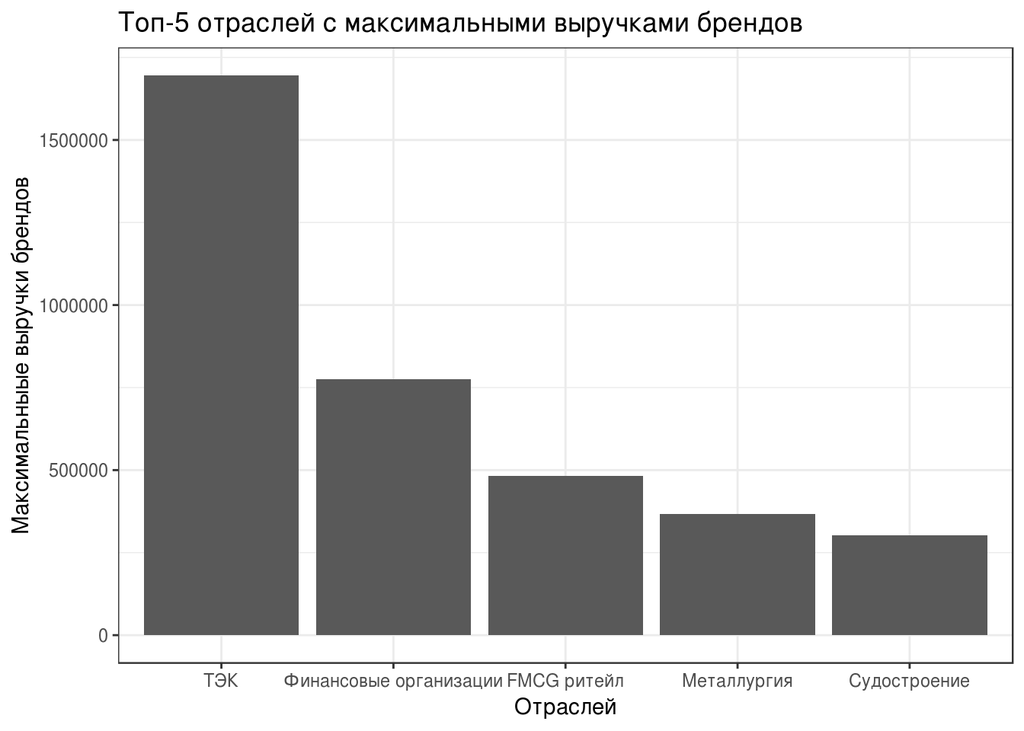

```r
ggplot(data = top5)+
  geom_bar(aes(x = reorder(industry, -profit, max), y = profit), stat = 'identity')+
  ggtitle("Топ-5 отраслей с максимальными выручками брендов")+
  xlab("Отраслей")+
  ylab("Максимальныые выручки брендов")+
  theme_bw()
```

## Часть 2. Вопросы и ответы

Итак, у нас есть данные, собранные с сайта stackoverflow.com. Это вопросы пользователей, связанные с написанием кода на языке R, ответы на эти вопросы, а также теги, которые были проставлены вопросам. В первую очередь, давайте подгрузим эти данные.

```r
library(dplyr)
questions <- read_csv("~/shared/minor2_2018/1-intro/data/questions_sample.csv")
answers <- read_csv("~/shared/minor2_2018/1-intro/data/answers_sample.csv")
tags <- read_csv("~/shared/minor2_2018/1-intro/data/tags_sample.csv")
questions = dplyr::select(questions, Id, OwnerUserId, Score:Body)
answers = dplyr::select(answers, ParentId, OwnerUserId, answer.score = `Score`, accepted = `IsAcceptedAnswer`, answer.body = `Body`)
```

А теперь нам их надо соединить. Благо, в пакете `dplyr` для этого есть функция join. Давайте при ее помощи сделаем один датасет, в котором будут вопросы и теги для них.

```r
?left_join
```

```r
qtags = left_join(questions, tags, by=NULL)
qtags
```

```
## # A tibble: 1,761 x 6
##        Id OwnerUserId Score Title  Body                              Tag
##     <int>       <int> <int> <chr>  <chr>                             <chr>
##  1  77434       14008   171 How t… "<p>Suppose I have a vector that… vect…
##  2  79709          NA     3 Worse… "<p>I have a function inside a l… memo…
##  3  79709          NA     3 Worse… "<p>I have a function inside a l… func…
##  4  79709          NA     3 Worse… "<p>I have a function inside a l… glob…
##  5  79709          NA     3 Worse… "<p>I have a function inside a l… side…
##  6  95007       15842    56 Expla… "<p>I've been mystified by the R… math
##  7  95007       15842    56 Expla… "<p>I've been mystified by the R… stat…
##  8 103312          NA     4 How t… "<p>How can I test for the <code… file
##  9 103312          NA     4 How t… "<p>How can I test for the <code… file…
## 10 103312          NA     4 How t… "<p>How can I test for the <code… eof
## # ... with 1,751 more rows
```

Теперь давайте найдем самые популярные теги (те, которые чаще всего встречаются в нашем новом датасете). Сделайте bar plot, в котором по оси X будут 10 самых популярных тегов, а ось Y будет показывать, сколько раз они встречаются. Остортируйте столбы по убыванию. Не забудьте удалить NA!

```r
p = qtags %>% group_by(Tag) %>% summarise(count = n()) %>% arrange(-count)%>% na.omit() %>% top_n(10)
```

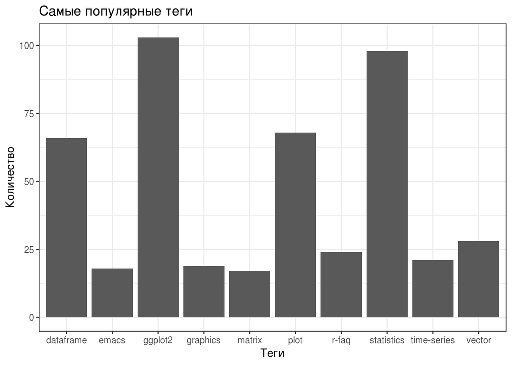

```r
ggplot(data = p)+
  geom_bar(aes(x = Tag, y = count), stat = 'identity')+
  ggtitle("Самые популярные теги")+
  xlab("Теги")+
  ylab("Количество")+
  theme_bw()
```

Теперь объединим вопросы и ответы и удалим NA для всего нового датасета.

```r
qans = left_join(questions, answers, by = NULL)
qans = na.omit(qans)
```

Давайте посмотрим, связана ли длина текста ответа с его рейтингом (Score). Для того, чтобы узнать, сколько символов в тексте ответа, нужно использовать функцию stringr::str_length. Какой график наиболее нам подходит для того, чтобы посмотреть связь между двумя количественными переменными? Покрасьте цветом ответы в зависимости от того, были ли они приняты автором вопроса или нет (accepted).

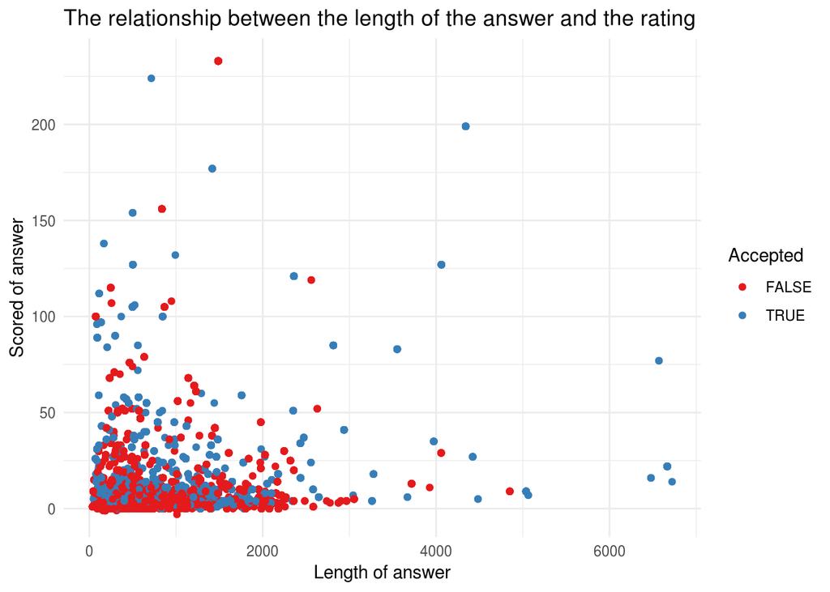

```r
qans = mutate(qans, len_ans = stringr::str_length(answer.body))
u = quantile(qans$answer.score, 0.99)
v = quantile(qans$len_ans, 0.995)
p = qans %>% filter(qans$answer.score <= u)
p = p %>% filter(p$len_ans <= v)
ggplot(data = p) + geom_point(aes(x = len_ans, y = answer.score, colour = accepted))+
  scale_color_brewer(name = "Accepted", palette = "Set1")+
  theme_minimal()+
  xlab("Length of answer")+
  ylab("Scored of answer")+
  ggtitle("The relationship between the length of the answer and the rating")
```

Задайте вопрос к данным по StackOverflow и ответьте на него.

Найти топ-10 самых популярных тег

```r
z = tags%>%group_by(Tag)%>%summarise(count = n())%>% arrange(-count)%>%top_n(10)
z
```

```
## # A tibble: 10 x 2
##    Tag         count
##    <chr>       <int>
##  1 ggplot2       103
##  2 statistics     98
##  3 plot           68
##  4 dataframe      66
##  5 vector         28
##  6 r-faq          24
##  7 time-series    21
##  8 graphics       19
##  9 emacs          18
## 10 matrix         17
```

А теперь давайте соберем html-отчет и попробуем поделиться им с помощью гистов. Инструкцию как пользоваться гистами можно найти тут “~/shared/minor2_2018/gists.pdf”

Не забываем – для создания html-отчета, нужно чтобы файлик RMarkdown у вас был сохранен в домашней папке.

Также, многие из вас интересовались, за что отвечают разные мистические надписи, вроде `echo = T` в заголовках чанков (серых кусков с кодом в .Rmd файлах, обозначающиеся ```). Давайте подсмотрим в шпаргалку и поэкспериментируем!